# Final Project - Tools for Data Science

Clayton Carpenter

03/03/2022

In this project you will be working with R, SQL, and Python in the same document. We will use the data sets *airlines* and *flights* from the package *nycflights13*

**Install the packages `nycflights13`, `sqldf`, `tydiverse` and load all data sets and packages**. Take your time to understand the data sets.

```r
# Install code here - comment the code when you installed

#install.packages("nycflights13")
#install.packages("sqldf")
#install.packages("tidyverse")

# Load all packages here

library(nycflights13)
library(sqldf)
library(tidyverse)

# Load the data here

data(airlines)
data(flights)
```

### R solution

You can use the R command `inner_join()` to join the two tables.

```r
library(dplyr)

flightsDF <- data.frame(flights) #loading in the data
airlinesDF <- data.frame(airlines)

joinedDF = inner_join(flightsDF, airlinesDF, by='carrier') %>% filter(dest == 'ATL') %>%  select(name,arr_delay) #joining data, filtering by destination and selecting name and arrival delay

joinedDF %>% group_by(name) %>%  summarise_each(funs(mean(., na.rm = TRUE))) %>% arrange(desc(arr_delay)) #grouping data by name and calculating the mean
```

```
## # A tibble: 7 x 2
##   name                        arr_delay
##   <chr>                           <dbl>
## 1 AirTran Airways Corporation    20.7
## 2 ExpressJet Airlines Inc.       19.6
## 3 Envoy Air                      14.0
## 4 United Air Lines Inc.          10.5
## 5 Delta Air Lines Inc.            7.42
## 6 Southwest Airlines Co.          6.90
## 7 Endeavor Air Inc.               0.857
```

### SQL solution

Write your SQL query in the function `sqldf()`. For exmaple,`sqldf("select * from relig_income")` list the data frame `relig_income`.

```r
# Example
# sqldf("select * from relig_income limit 3")
# code here


#selecting airline name and average delay
sqldf("
      Select airlns.name, AVG(flgt.arr_delay)
      FROM flights as flgt
      LEFT JOIN airlines as airlns --joining data on carrier
      on flgt.carrier = airlns.carrier
      WHERE flgt.dest == 'ATL' --filtering by destination
      GROUP BY airlns.name --grouping by airline
      ORDER BY AVG(flgt.arr_delay) DESC --ordering the data by arrival delays
      ")
```

```
##                          name AVG(flgt.arr_delay)
## 1 AirTran Airways Corporation          20.7445127
## 2    ExpressJet Airlines Inc.          19.6382850
## 3                   Envoy Air          14.0340045
## 4       United Air Lines Inc.          10.5000000
## 5        Delta Air Lines Inc.           7.4242250
## 6      Southwest Airlines Co.           6.8965517
## 7           Endeavor Air Inc.           0.8571429
```

### Python solution

Use [df.join()](https://pandas.pydata.org/docs/reference/api/pandas.DataFrame.join.html) from pandas.

```python
# load python libraries

import pandas as pd
import statsmodels.api as stat

# load data
flights_df = stat.datasets.get_rdataset("flights", "nycflights13").data
airlines_df = stat.datasets.get_rdataset("airlines", "nycflights13").data

# code here
joined_df = flights_df.set_index('carrier').join(airlines_df.set_index('carrier'), how='inner') #joining airlines and flight data

joined_df = joined_df[joined_df['dest'] == 'ATL'] #filtering the data for ATL as destination

joined_df.groupby('name')['arr_delay'].mean().reset_index().sort_values('arr_delay', ascending=False) #grouping by name and calculating the mean
```

```
##                           name  arr_delay
## 0  AirTran Airways Corporation  20.744513
## 4     ExpressJet Airlines Inc.  19.638285
## 3                    Envoy Air  14.034004
## 6        United Air Lines Inc.  10.500000
## 1         Delta Air Lines Inc.   7.424225
## 5       Southwest Airlines Co.   6.896552
## 2            Endeavor Air Inc.   0.857143
```

### R solution

Use ggplot

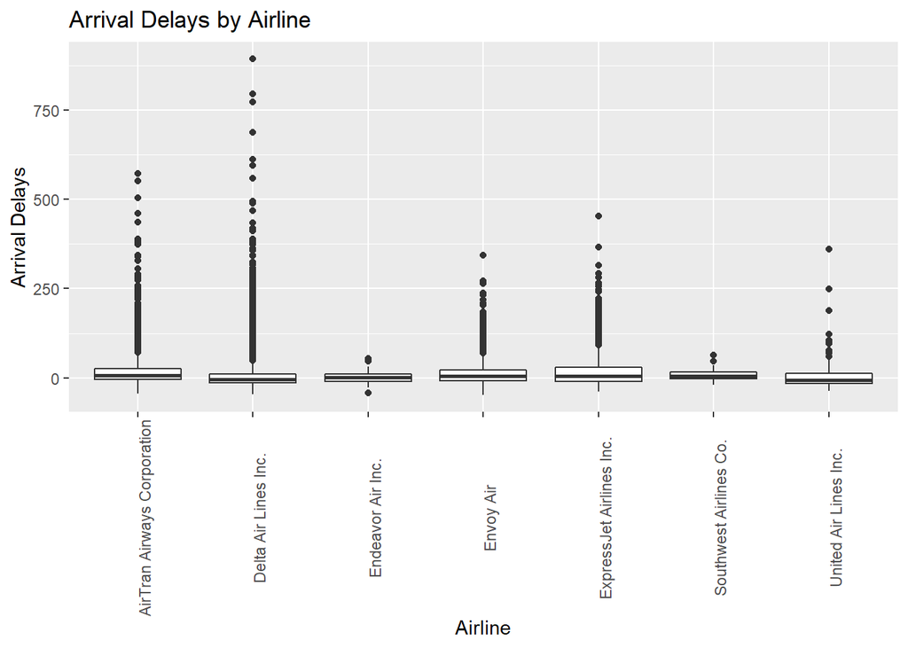

```r
# code here
library(ggplot2) #loading ggplot2

plot <- ggplot(data = joinedDF, aes(x = name, y = arr_delay, ymin = -500)) + #plotting data
  geom_boxplot() +
  labs(title="Arrival Delays by Airline", #setting labels
       x="Airline",
       y = "Arrival Delays") +
  theme(axis.text.x = element_text(angle = 90)) #rotating x axis labels

plot
```

### Python solution

You can use [pandas.boxplot()](https://pandas.pydata.org/docs/reference/api/pandas.DataFrame.boxplot.html) or [seaborn.boxplot()](https://seaborn.pydata.org/generated/seaborn.boxplot.html).

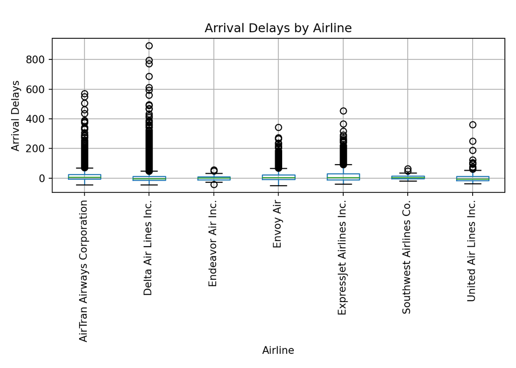

```python
# import python libraries
import matplotlib.pyplot as plt #importing library used to create box plot
# data

#the data utilizes the joined_df created on line 75

# Boxplot

plt.figure() #initializing figure
joined_df.boxplot(column=['arr_delay'], by="name",rot=90) #using the boxplot method to create a boxplot

#setting lables for the plot
plt.xlabel("Airline")
plt.ylabel("Arrival Delays")
plt.suptitle('')
plt.title("Arrival Delays by Airline")
plt.tight_layout()

plt.show() #displaying box plot
```